# Problem Set 2: Time Series

EC 421: Introduction to Econometrics

Author

Edward Rubin

## 1 Instructions

**Due** Upload your answer on Canvas *before* midnight on Tuesday, 26 May 2026.

**Important** **Submit** your answers as an **HTML or PDF file**. The submitted file should be built from an RMarkdown (`.rmd`) or Quarto (`.qmd`) file. Do not submit the `.rmd` or `.qmd` file. You will not receive credit for it.

If we ask you to create a figure or run a regression, then the figure or the regression results should be in the document that you submit (not just the code—we want the actual figure or regression output with coefficients, standard errors, *etc.*).

**Integrity** If you are suspected of cheating, then you will receive a zero—for the assignment and possibly for the course. We may report you to the dean. Cheating includes copying from your classmates, from the internet, and from previous assignments.

**README!** The data for this problem set come from the Federal Reserve Bank of St. Louis [FRED database](https://fred.stlouisfed.org/). The dataset contains **monthly** U.S. macroeconomic variables.

The table below describes each variable.

Variable names and descriptions

| Variable name | Description |
| --- | --- |
| `date` | Month of sample (*e.g.*, ‘1990-01-01’) |
| `time` | *Time* in the dataset, by month (starting January 1990) |
| `country` | Country (always ‘US’) |
| `housing` | [New Privately-Owned Housing Units Started: Total Units (HOUST)](https://fred.stlouisfed.org/series/HOUST) (1,000s) |
| `mortgage_rate` | [30-Year Fixed Rate Mortgage Average in the United States (MORTGAGE30US)](https://fred.stlouisfed.org/series/MORTGAGE30US) (percent) |
| `cpi` | [Consumer Price Index (CPI) for All Urban Consumers: All Items in U.S. City Average (CPIAUCSL)](https://fred.stlouisfed.org/series/CPIAUCSL) (index: 1982–84 = 100) |
| `industry` | [Industrial Production: Total Index](https://fred.stlouisfed.org/series/INDPRO) (index: 2017 = 100) |
| `unemp` | [Unemployment Rate (UNRATE)](https://fred.stlouisfed.org/series/UNRATE) (percent) |
| `recession` | [NBER-based Recession Indicators for the United States from the Period following the Peak through the Trough (USREC)](https://fred.stlouisfed.org/series/USREC) (binary) |

**Objective** This problem set has four purposes:

1. Strengthen your understanding of time-series properties (trend, persistence, stationarity).
2. Practice dynamic regression modeling.
3. Learn to implement and interpret Newey–West standard errors using `fixest`.
4. Develop your judgment about which regression specifications are reasonable in macroeconomic time-series settings.

## 2 Setup

Load the dataset `data-ps2.csv`–and any `R` packages you need (at least `tidyverse`, `here`, and `fixest`).

Answer I’m using `read_csv()` from the `tidyverse` package to load the data.

```r
# Load packages using 'pacman'
library(pacman)
p_load(tidyverse, patchwork, scales, fixest, here)
# Load the data
ps_df = here('problem-sets', '002', 'data-ps2.csv') %>% read_csv()
```

What time period do the data cover? How many months are in the sample?

Note that (1) each row represents a month and (2) the data are already sorted by date/time.

Answer The data cover 1990-01-01 to 2025-12-01. There are 432 months in the sample.

```r
# First observation
ps_df |> head(1)
```

```
# A tibble: 1 × 9
  date        time country housing mortgage_rate   cpi industry unemp recession
  <date>     <dbl> <chr>     <dbl>         <dbl> <dbl>    <dbl> <dbl>     <dbl>
1 1990-01-01     1 US         1551           9.9  128.     61.7   5.4         0
```

```r
# Last observation
ps_df |> tail(1)
```

```
# A tibble: 1 × 9
  date        time country housing mortgage_rate   cpi industry unemp recession
  <date>     <dbl> <chr>     <dbl>         <dbl> <dbl>    <dbl> <dbl>     <dbl>
1 2025-12-01   432 US         1373          6.19  326.     102.   4.4         0
```

```r
# Number of months
nrow(ps_df)
```

```
[1] 432
```

How many “complete” observations are there in the sample? In other words, after dropping missing values, how many observations remain?

Answer I’m using `drop_na()` to drop missing values, then `nrow()` to count the number of observations. We have 431 complete observations.

```r
# Drop rows missing values and count the number of observations
ps_df |> drop_na() |> nrow()
```

```
[1] 431
```

For each of the “economic” variables (ignoring `date`, `time`, and `country`), report the mean *and* interpret it (putting it in the context of its units).

Note that the variable-description table above describes each of the variables and links to the “FRED” page.

*Hint:* Use `mean()` with `na.rm = TRUE` to compute the mean, ignoring missing values.

Answer The variables are

- `housing`: The average number of new housing constructions in a month was 1,325,692.
- `mortgage_rate`: The average 30-year mortgage rate was 6.02 percent.
- `cpi`: The average CPI during the sample period was 209.99 (relative to “100” in the base years 1982–1984).
- `industry`: The average industry production index was 90.33 (relative to 100 in the base year of 2017).
- `unemp`: The average unemployment rate was 5.68 percent.
- `recession`: The average of recession indicator was 8.33%. Thus, 8.33% of months were recession months.

## 3 Time-series plots

Create time-series plots for:

- the number of monthly housing starts (`housing`),
- the 30-year mortgage rate (`mortgage_rate`),
- the CPI (`cpi`),
- the industry production index (`industry`),
- the unemployment rate (`unemp`).

You should have five separate plots: one for each variable.

Use properly labeled axes and titles.

Answer I’m using `ggplot2` to create the time-series plots.

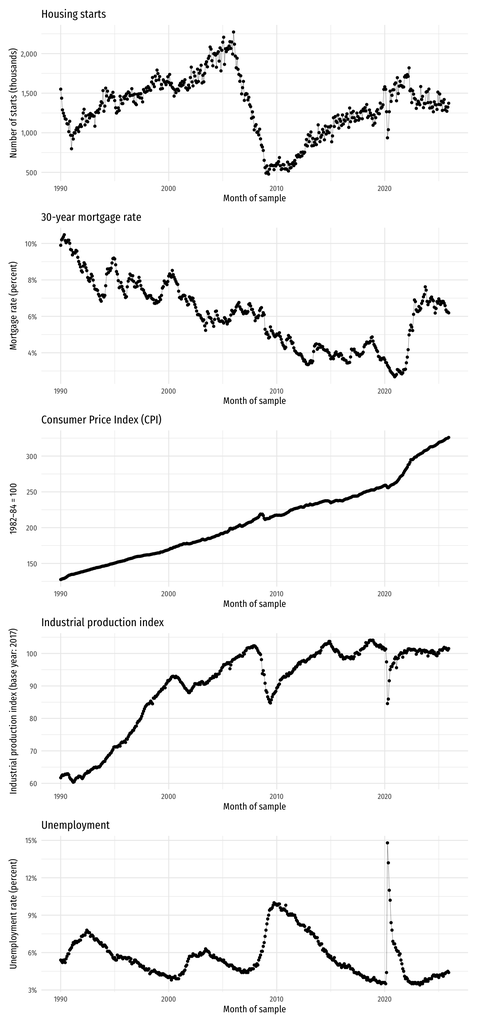

```r
# Housing starts
hs =
  ggplot(ps_df, aes(x = date, y = housing)) +
  geom_line(linewidth = .1) +
  geom_point(size = 1) +
  labs(
    title = 'Housing starts',
    x = 'Month of sample',
    y = 'Number of starts (thousands)'
  ) +
  scale_y_continuous(labels = scales::comma_format(scale = 1)) +
  theme_minimal(
    base_size = 10,
    base_family = 'Fira Sans Condensed'
  )
# 30-year mortgage rate
mr =
  ggplot(ps_df, aes(x = date, y = mortgage_rate)) +
  geom_line(linewidth = .1) +
  geom_point(size = 1) +
  labs(
    title = '30-year mortgage rate',
    x = 'Month of sample',
    y = 'Mortgage rate (percent)'
  ) +
  scale_y_continuous(labels = scales::percent_format(scale = 1)) +
  theme_minimal(
    base_size = 10,
    base_family = 'Fira Sans Condensed'
  )
# CPI
cpi =
  ggplot(ps_df, aes(x = date, y = cpi)) +
  geom_line(linewidth = .1) +
  geom_point(size = 1) +
  labs(
    title = 'Consumer Price Index (CPI)',
    x = 'Month of sample',
    y = '1982–84 = 100'
  ) +
  scale_y_continuous(labels = scales::comma_format(scale = 1)) +
  theme_minimal(
    base_size = 10,
    base_family = 'Fira Sans Condensed'
  )
# Industrial production index
ind =
  ggplot(ps_df, aes(x = date, y = industry)) +
  geom_line(linewidth = .1) +
  geom_point(size = 1) +
  labs(
    title = 'Industrial production index',
    x = 'Month of sample',
    y = 'Industrial production index (base year: 2017)'
  ) +
  scale_y_continuous(labels = scales::comma_format(scale = 1)) +
  theme_minimal(
    base_size = 10,
    base_family = 'Fira Sans Condensed'
  )
# Unemployment
ue =
  ggplot(ps_df, aes(x = date, y = unemp)) +
  geom_line(linewidth = .1) +
  geom_point(size = 1) +
  labs(
    title = 'Unemployment',
    x = 'Month of sample',
    y = 'Unemployment rate (percent)'
  ) +
  scale_y_continuous(labels = scales::percent_format(scale = 1)) +
  theme_minimal(
    base_size = 10,
    base_family = 'Fira Sans Condensed'
  )
# Combine the plots
hs / mr / cpi / ind / ue
```

For each variable, describe whether it appears to:

- trend upward/downward with time,
- follow any notable patterns or cycles,
- exhibit strong persistence (*i.e.*, is strongly autocorrelated),
- exhibit any other notable features.

Be specific. Do not just say “yes” or “no.”

Based on the plots alone, which variables appear likely to be non-stationary in levels (in their means)? Explain your reasoning.

Answer Based on the plots, housing starts, the 30-year mortgage rate, the CPI, and the industry production index appear to be non-stationary in levels. Each exhibits a clear trend over time.

How do the Great Recession/Financial Crisis and the COVID-19 Pandemic appear to affect each of the five time-series?

Answer The Great Recession (approx. 2007–2009) coincided with a huge drop in housing starts. The housing market still has not reached pre-2007 levels. The industrial production index also sharply dropped and unemployment quickly increased. The Great Recession only shows up as a small blip in CPI.

The COVID-19 Pandemic (approx. 2020–2022) accompanied a much smaller and shorter-lasting impact on housing starts. The industrial production index was similar in size but much shorter lived. The unemployment rate skyrocketed during the pandemic but also recovered quite quickly. Finally, the CPI appears to have taken on new, steeper trends during and after the pandemic.

## 4 Transformations

Create five new variables:

1. **Change in housing starts**, `diff_housing`: $\Delta\texttt{housing}_t$.  
   This variable is the difference between the current and previous housing starts values.
2. **Change in the 30-year mortgage rate**, (`diff_mr`): $\Delta\texttt{mortgage\_rate}_t$.  
   This variable is the difference between the current and previous mortgage rates.
3. **Inflation**, `infl`: $100\times\dfrac{\Delta\texttt{cpi}_t}{\texttt{cpi}_{t-1}}$  
   This variable is the percent change in the CPI, which is a common measure of inflation (units are percent).
4. **Change in industry production index**, (`diff_industry`): $\Delta\texttt{industry}_t$.  
   This variable is the difference between the current and previous industry production index values.
5. **Change in unemployment rate**, `diff_unemp`: $\Delta\texttt{unemp}_t$.  
   This variable is the difference between the current and previous unemployment rates.

**Important**

- Remember that $\Delta x_t$ means the *difference* between $x_t$ and its lag. So, $\Delta x_t = x_t - x_{t-1}$ and $\Delta\log(x_t) = \log(x_t) - \log(x_{t-1})$.
- It may also be helpful to remember that differences in logs equal the log of the ratio: $\Delta\log(x_t) = \log(x_t) - \log(x_{t-1}) = \log\left(\frac{x_t}{x_{t-1}}\right)$.

**Hint**: You can use `dplyr::mutate()` to create new variables. You can use `lag()` to access lagged values. It may be helpful to create intermediate (lagged) variables before moving on to the final transformations.

Answer Let’s create the variables.

```r
# Start with lags; then compute desired variables
ps_df =
  ps_df |>
  mutate(
    lag_housing = lag(housing),
    lag_mortgage_rate = lag(mortgage_rate),
    lag_cpi = lag(cpi),
    lag_industry = lag(industry),
    lag_unemp = lag(unemp),
    diff_housing = housing - lag_housing,
    diff_mr = mortgage_rate - lag_mortgage_rate,
    infl = 100 * (cpi - lag_cpi) / lag_cpi,
    diff_industry = industry - lag_industry,
    diff_unemp = unemp - lag_unemp
  )
```

Now make time-series plots of the five new variables.

Answer

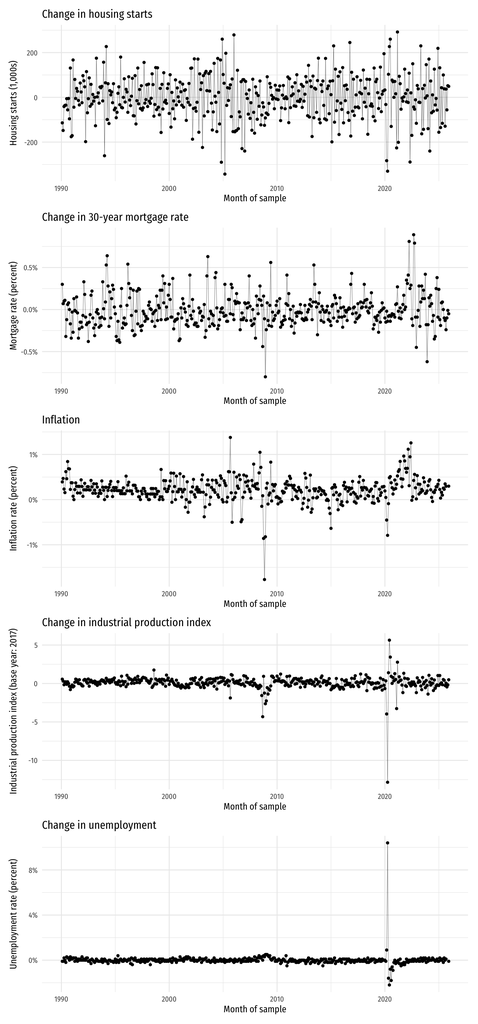

```r
# Housing starts growth
hs =
  ggplot(ps_df, aes(x = date, y = diff_housing)) +
  geom_line(linewidth = .1) +
  geom_point(size = 1) +
  labs(
    title = 'Change in housing starts',
    x = 'Month of sample',
    y = 'Housing starts (1,000s)'
  ) +
  scale_y_continuous(labels = scales::comma_format(scale = 1)) +
  theme_minimal(
    base_size = 10,
    base_family = 'Fira Sans Condensed'
  )
# Diff 30-year mortgage rate
mr =
  ggplot(ps_df, aes(x = date, y = diff_mr)) +
  geom_line(linewidth = .1) +
  geom_point(size = 1) +
  labs(
    title = 'Change in 30-year mortgage rate',
    x = 'Month of sample',
    y = 'Mortgage rate (percent)'
  ) +
  scale_y_continuous(labels = scales::percent_format(scale = 1)) +
  theme_minimal(
    base_size = 10,
    base_family = 'Fira Sans Condensed'
  )
# Inflation
cpi =
  ggplot(ps_df, aes(x = date, y = infl)) +
  geom_line(linewidth = .1) +
  geom_point(size = 1) +
  labs(
    title = 'Inflation',
    x = 'Month of sample',
    y = 'Inflation rate (percent)'
  ) +
  scale_y_continuous(labels = scales::percent_format(scale = 1)) +
  theme_minimal(
    base_size = 10,
    base_family = 'Fira Sans Condensed'
  )
# Diff industrial production index
ind =
  ggplot(ps_df, aes(x = date, y = diff_industry)) +
  geom_line(linewidth = .1) +
  geom_point(size = 1) +
  labs(
    title = 'Change in industrial production index',
    x = 'Month of sample',
    y = 'Industrial production index (base year: 2017)'
  ) +
  scale_y_continuous(labels = scales::comma_format(scale = 1)) +
  theme_minimal(
    base_size = 10,
    base_family = 'Fira Sans Condensed'
  )
# Diff unemployment
ue =
  ggplot(ps_df, aes(x = date, y = diff_unemp)) +
  geom_line(linewidth = .1) +
  geom_point(size = 1) +
  labs(
    title = 'Change in unemployment',
    x = 'Month of sample',
    y = 'Unemployment rate (percent)'
  ) +
  scale_y_continuous(labels = scales::percent_format(scale = 1)) +
  theme_minimal(
    base_size = 10,
    base_family = 'Fira Sans Condensed'
  )
# Combine the plots
hs / mr / cpi / ind / ue
```

Did the transformations help to stabilize the time series? Explain your answer.

Answer For the most part, it seems like the transformations helped a lot. We might still be worried about variance- and covariance-based non-stationarity, but the transformations seem to have made the series more stable in terms of their means

## 5 Time-series models

Let’s start with a *static* model with the *untransformed* variables. Estimate the following model:

$$\begin{aligned}
\text{housing}_t = &\beta_0 + \\
&\beta_1 (\text{mortgage rate})_t + \\
&\beta_2 (\text{industrial production})_t + \\
&\beta_3 \text{unemployment}_t + u_t
\end{aligned}$$

Report your estimates as a table.

Answer

```r
# The requested regression
reg_static =
  feols(
    housing ~ mortgage_rate + industry + unemp,
    data = ps_df
  )
```

```
NOTE: 1 observation removed because of NA values (RHS: 1).
```

```r
# Display the regression results
reg_static |> etable()
```

```
                        reg_static
Dependent Var.:            housing

Constant        2,371.7*** (317.4)
mortgage_rate        8.834 (14.60)
industry            -3.546 (2.156)
unemp            -137.2*** (10.93)
_______________ __________________
S.E. type                      IID
Observations                   431
R2                         0.38735
Adj. R2                    0.38305
---
Signif. codes: 0 '***' 0.001 '**' 0.01 '*' 0.05 '.' 0.1 ' ' 1
```

Interpret the coefficients from the preceding regression.

Answer

- `mortgage_rate`: a one-unit increase in mortgage rate (an increase in the mortgage rate by one percentage point) is associated with a 8.8-thousand increase in monthly housing starts (not statistically significant at the 5% level).
- `industry`: a one-unit increase in industry production index is associated with a 3.5-thousand reduction in monthly housing starts (not statistically significant at the 5% level).
- `unemp`: a one-unit increase in unemployment (a one-percentage-point increase in the unemployment rate) is associated with a 137.2-thousand reduction in monthly housing starts (statistically significant at the 5% level).

Why should we be concerned about non-stationarity in the context of this regression? Explain the concern and why it is relevant here.

Answer The figures above are highly suggestive of non-stationarity in these data. If we regress one non-stationary variable on another, OLS may find spurious correlations.

How can you address the non-stationarity issue in this regression?

Answer One way to address non-stationarity is to difference the variables and regress the differenced variables on each other. Another approach is to control for time trends, seasonality, and other non-stationary components in the data.

Let’s now estimate *differenced* version of the preceding model, *i.e.*,

$$\begin{aligned}
\Delta \text{housing}_t = &\beta_0 + \\
&\beta_1 \Delta (\text{mortgage rate})_t + \\
&\beta_2 \Delta (\text{industrial production index})_t + \\
&\beta_3 \Delta \text{unemployment}_t + \Delta u_t
\end{aligned}$$

Report your estimates as a table.

To be clear, this model uses the transformed variables from above: your outcome is the change in housing starts (`diff_housing`), and the right-hand-side variables are three of your “new” variables.

Answer

```r
# The requested regression
reg_static_diff =
  feols(
    diff_housing ~ diff_mr + diff_industry + diff_unemp,
    data = ps_df
  )
```

```
NOTE: 3 observations removed because of NA values (LHS: 1, RHS: 3).
```

```r
# Display the regression results
reg_static_diff |> etable()
```

```
                 reg_static_diff
Dependent Var.:     diff_housing

Constant          -4.341 (4.635)
diff_mr          -41.60. (23.14)
diff_industry   38.39*** (7.361)
diff_unemp         12.20 (12.46)
_______________ ________________
S.E. type                    IID
Observations                 429
R2                       0.10082
Adj. R2                  0.09447
---
Signif. codes: 0 '***' 0.001 '**' 0.01 '*' 0.05 '.' 0.1 ' ' 1
```

Interpret the coefficients from the differenced regression.

Answer The key insight here is that the interpretation of the coefficients in the differenced regression is the same as in the static regression.

Are the coefficient estimates from the differenced regression meaningfully different from the original static (un-differenced) regression?

Answer Yes! The magnitudes and signs of the coefficients have changed and *which* coefficients are statistically significant have changed.

How would an autocorrelated disturbance affect OLS in this setting?

Answer Autocorrelated disturbances *in static* models can lead to biased standard-error estimates and inefficiency (still unbiased/consistent for estimating the coefficients).

Perform a test for first-order autocorrelation in the residuals of the differenced static model.

**Note:** If you are going to add the residuals to the dataset, you will need to do one of the following to make sure you get the right number of observations:

- use the `na.rm = FALSE` argument in `residuals()` function, *e.g.*, `residuals(model_static, na.rm = FALSE)`, which will return `NA` for the first observation (since the first observation of the dependent variable is a difference, it cannot be calculated for the first quarter);
- directly add the `NA` to the residuals vector on your own, *e.g.*, `c(NA, residuals(model_static))`.

**Another note/hint:** To regress a variable on its own lag, you can do one of the following:

- Create a new variable that is the lag of the residuals, *e.g.*, `lag_e = lag(e)`, and then regress `e` on `lag_e`.
- Use the `l()` function in `fixest` to create the lag directly in the regression, *e.g.*, `feols(e ~ l(e, 1), data = ps_df, panel.id = ~ country + time)`, which will regress the residuals on their own first lag. Notice that you need to define the `panel.id` argument in this case.
- Use the `lag` function (from `tidyverse`) within `lm`, *e.g.*, `lm(e ~ lag(e, 1), data = ps_df)`.

Answer

```r
# Add the residuals to the dataset
ps_df$e = residuals(reg_static_diff, na.rm = FALSE)
# Regress the residuals on their own lag
reg_bg_ar1 =
  feols(
    e ~ l(e, 1),
    data = ps_df[-1, ],
    panel.id = ~ country + time,
    vcov = 'iid'
  )
```

```
NOTE: 4 observations removed because of NA values (LHS: 2, RHS: 3).
```

```r
etable(reg_bg_ar1)
```

```
                         reg_bg_ar1
Dependent Var.:                   e

Constant             0.1367 (4.186)
l(e,1)          -0.4055*** (0.0442)
_______________ ___________________
S.E. type                       IID
Observations                    427
R2                          0.16503
Adj. R2                     0.16307
---
Signif. codes: 0 '***' 0.001 '**' 0.01 '*' 0.05 '.' 0.1 ' ' 1
```

We find **strong** evidence of autocorrelation—with a large, negative coefficient on the lag of the residuals (suggesting negative autocorrelation).

Update your *differenced* regression to use Newey-West standard errors and compare the results with the original regression.

Remember that you can use `vcov = 'nw'` with `feols` to obtain Newey-West standard errors, for example,

```r
feols(
  y ~ x + l(x),
  data = fake_data,
  panel.id = ~ country + time,
  vcov = 'nw'
)
```

Answer

```r
# Estimate the model with Newey-West standard errors
reg_static_diff_nw =
  feols(
    diff_housing ~ diff_mr + diff_industry + diff_unemp,
    data = ps_df,
    vcov = 'nw',
    panel.id = ~ country + time
  )
```

```
NOTE: 3 observations removed because of NA values (LHS: 1, RHS: 3).
```

```r
etable(
  reg_static_diff,
  reg_static_diff_nw
)
```

```
                 reg_static_diff reg_static_dif..
Dependent Var.:     diff_housing     diff_housing

Constant          -4.341 (4.635)   -4.341 (3.023)
diff_mr          -41.60. (23.14)  -41.60* (18.65)
diff_industry   38.39*** (7.361) 38.39*** (9.542)
diff_unemp         12.20 (12.46)    12.20 (13.05)
_______________ ________________ ________________
S.E. type                    IID Newey-West (L=4)
Observations                 429              429
R2                       0.10082          0.10082
Adj. R2                  0.09447          0.09447
---
Signif. codes: 0 '***' 0.001 '**' 0.01 '*' 0.05 '.' 0.1 ' ' 1
```

The Newey-West standard errors are quite different from the default OLS standard errors: the effect of the mortgage rate is more significant (the standard error is about 20% smaller). The standard error on industry index is about 30% larger.

Suppose you were interested in adding lags for each of the three explanatory variables and estimate the model
$$\begin{aligned}
\Delta \text{housing}_t = &\beta_0 + \\
&\beta_1 \Delta (\text{mortgage rate})_t + \\
&\beta_2 \Delta (\text{industrial production index})_t + \\
&\beta_3 \Delta \text{unemployment}_t \\
&\beta_4 \Delta (\text{mortgage rate})_{t-1} + \\
&\beta_5 \Delta (\text{industrial production index})_{t-1} + \\
&\beta_6 \Delta \text{unemployment}_{t-1} + \Delta u_t
\end{aligned}$$
How would autocorrelation affect OLS when estimating this new model?

Answer Autocorrelation would have the same effect as in the static model: OLS would be biased for estimating the standard errors and inefficient (but still unbiased and consistent for estimating the coefficients).

Now suppose you instead add a lag for the outcome (`diff_housing`).
$$\begin{aligned}
\Delta \text{housing}_t = &\beta_0 + \\
&\beta_1 \Delta (\text{mortgage rate})_t + \\
&\beta_2 \Delta (\text{industrial production index})_t + \\
&\beta_3 \Delta \text{unemployment}_t \\
&\beta_4 \Delta \text{housing}_{t-1} + \Delta u_t
\end{aligned}$$
Is OLS unbiased in this case? Is it consistent? Explain your answer.

Answer Because we now have a lagged outcome variable, OLS is biased for the *coefficients*. *If we have autocorrelation*, OLS will be inconsistent as well.

Consider the two regressions below (and their results). What do the regressions tell us about non-stationarity of `housing` and `diff_housing`?

```r
#|label: 'reg-compare'

feols(
  housing ~ l(housing, 1),
  data = ps_df,
  panel.id = ~ country + time,
  vcov = 'iid'
) |> etable()
```

```
NOTE: 1 observation removed because of NA values (RHS: 1).
```

```
                feols(housing ~ ..
Dependent Var.:            housing

Constant           46.06** (17.36)
l(housing,1)    0.9649*** (0.0126)
_______________ __________________
S.E. type                      IID
Observations                   431
R2                         0.93185
Adj. R2                    0.93169
---
Signif. codes: 0 '***' 0.001 '**' 0.01 '*' 0.05 '.' 0.1 ' ' 1
```

```r
feols(
  diff_housing ~ l(diff_housing, 1),
  data = ps_df,
  panel.id = ~ country + time,
  vcov = 'iid'
) |> etable()
```

```
NOTE: 2 observations removed because of NA values (LHS: 1, RHS: 2).
```

```
                  feols(diff_housin..
Dependent Var.:          diff_housing

Constant              -0.3480 (4.446)
l(diff_housing,1) -0.3772*** (0.0447)
_________________ ___________________
S.E. type                         IID
Observations                      430
R2                            0.14266
Adj. R2                       0.14065
---
Signif. codes: 0 '***' 0.001 '**' 0.01 '*' 0.05 '.' 0.1 ' ' 1
```

Answer Both regressions are akin to a Dickey-Fuller test.

The first regression (on the level of housing starts) has a coefficient on the lag that is quite close to 1. We fail to reject *random walk*, meaning the *level* of housing starts is very likely non-stationary.

The second regression (on the first difference of housing starts) has a coefficient on the lag that rejects 1: We reject *random walk*, meaning the *first difference* of housing starts may be stationary (at least is *not* a random walk).

## 6 Conclusion

Which of the models that we estimated and/or considered is the most appropriate for our setting—*i.e.*, which model would you choose to use in practice? Or would you choose a different model altogether? Explain.

Answer The plots and preceding regressions suggest that the raw data are not stationary, while the differenced data look less problematic. Thus, I would go with a model that uses the first differences.

Because we have significant evidence of autocorrelation, we probably want to stay away from models that use a lagged outcome variable.

Thus, I would go with a model that uses the differenced data in either a static specification or a lagged-explanatory-variables-only specification.